# Environmental Data in Brazil: Insights on Deforestation, Air Pollution, and Wildfires

Mateus Berutto Figueiredo

2025-03-15

## Introduction

This report provides a comprehensive overview of the available environmental data in Brazil, focusing on three key areas:

1. Deforestation in Federal Conservation Units (FCUs) – Examining data from the Instituto Chico Mendes de Conservação da Biodiversidade (ICMBio) to track forest loss across Brazil’s six main biomes.
2. Air Pollution Monitoring – Analyzing air quality data from the MonitorAr platform, developed by the Brazilian Ministry of the Environment, to assess pollution levels in major urban and industrial areas.
3. Wildfire Occurrence – Utilizing fire detection data from the Programa Queimadas (INPE) to visualize the spatial distribution of wildfires and their seasonal variations.

By compiling and visualizing these datasets, this report highlights the availability, scope, and limitations of environmental data in Brazil.

## Deforestation Data in Federal Conservation Units

This first dataset provides information on deforestation in Federal Conservation Units (FCUs). FCUs in Brazil are protected natural areas managed by the federal government to preserve biodiversity and promote sustainable use of resources. These units play a critical role in combating deforestation, preserving ecosystems, and supporting local communities while maintaining Brazil’s natural heritage.

The data used in this section come from the Instituto Chico Mendes de Conservação da Biodiversidade (ICMBio), a Brazilian government agency responsible for managing and protecting FCUs. ICMBio operates under the Ministry of the Environment and Climate Change and plays a key role in biodiversity conservation, environmental research, and sustainable development within Brazil’s protected areas. The data are available in the *Open Data* (i.e. Dados Abertos) section of the [gov.br](https://www.gov.br/pt-br) website. To access all data on deforestation in FCUs, click [here](https://dados.gov.br/dados/conjuntos-dados/desmatamento-em-unidades-de-conservacao-federais).

Brazil’s six main biomes where FCUs are located are Amazônia, Cerrado, Caatinga, Mata Atlântica, Pampa, and Pantanal.

1. The Amazônia (Amazon), covering the northern region (Amazonas, Pará, Acre, Rondônia, Roraima, Amapá, Tocantins, and Maranhão), is the world’s largest rainforest and a critical area for biodiversity and carbon storage.
2. Cerrado, a vast tropical savanna in the central region (Goiás, Mato Grosso, Mato Grosso do Sul, Tocantins, Minas Gerais, Bahia, Piauí, Maranhão, São Paulo, Paraná, and the Federal District), is known for its vegetation and agricultural expansion.
3. Caatinga, a semi-arid biome in the Northeast (Bahia, Ceará, Pernambuco, Piauí, Rio Grande do Norte, Paraíba, Alagoas, Sergipe, and Maranhão), is characterized by drought-resistant vegetation and endemic species.
4. Mata Atlântica, stretching along Brazil’s eastern coast (São Paulo, Rio de Janeiro, Espírito Santo, Paraná, Santa Catarina, Rio Grande do Sul, Minas Gerais, Bahia, Sergipe, Alagoas, Pernambuco, Paraíba, and Rio Grande do Norte), is a highly threatened forest with rich biodiversity.
5. Pampa, in the extreme south (Rio Grande do Sul), consists of grasslands and is essential for grazing and conservation.
6. Pantanal, in the Midwest (Mato Grosso and Mato Grosso do Sul), is the world’s largest tropical wetland and plays a key role in regulating water cycles and supporting diverse wildlife.

Data on deforestation are available for all FCUs in Brazil, categorized into the country’s six major biomes. For each unit, the government provides detailed figures on the total land area under federal protection and the extent of deforested land. Additionally, annual deforestation data (in hectares) are recorded for each unit, allowing for a comprehensive analysis of forest loss over time. The frequency of reporting varies by biome, but in most cases, updates have been released every two years over the past two decades, offering researchers insights into long-term deforestation trends. Notably, in the Pantanal, the government reports the cumulative deforested land up to the year 2000 but does not provide annual updates beyond that. This is because, according to official records, there was no deforestation in the FCUs of the Pantanal between 2001 and 2023.

To visualize these data, I created an interactive map displaying all FCUs in Brazil along with the percentage of land lost to deforestation. Each FCU is assigned a unique identification number (cnuc), which enables researchers, policymakers, and the public to easily access information about these protected areas. This identifier plays a key role in tracking deforestation trends, assessing conservation efforts, and monitoring land use changes across Brazil’s diverse biomes.

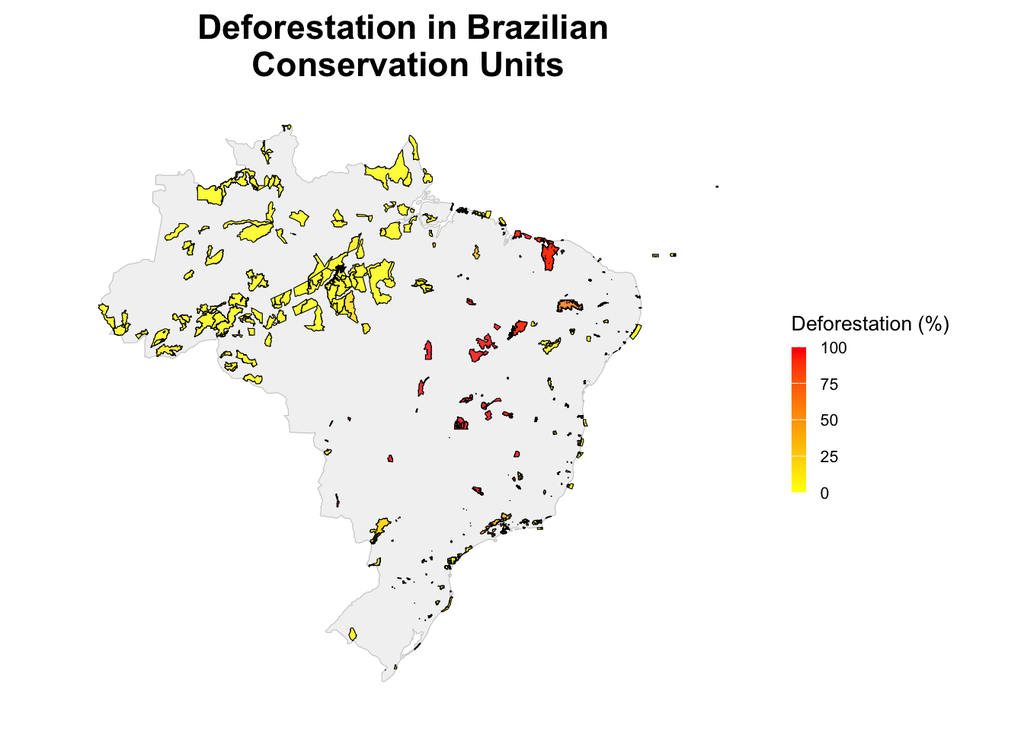

On the other end of the spectrum, some FCUs experienced complete deforestation (100%), meaning all their protected land was lost. These cases highlight the varying effectiveness of conservation policies and the intensity of external pressures such as land conversion, agriculture, and urban expansion. Here is the list of all FCUs with 100% deforestation.

| cnuc | Federal Conservation Unit | Biome |
| --- | --- | --- |
| 0000.00.0226 | RESEX da Mata Grande | Amazônia |
| 0000.00.1520 | RESEX do Quilombo Flexal | Amazônia |
| 0000.00.0020 | APA Carste de Lagoa Santa | Cerrado |
| 0000.00.0002 | APA Cavernas do Peruaçu | Cerrado |
| 0000.00.0003 | APA da Bacia do Rio Descoberto | Cerrado |
| 0000.00.0004 | APA da Bacia do Rio São Bartolomeu | Cerrado |
| 0000.00.0025 | APA das Ilhas e Várzeas do Rio Paraná | Cerrado |
| 0000.00.0028 | APA das Nascentes do Rio Vermelho | Cerrado |
| 0000.00.0019 | APA Delta do Parnaíba | Cerrado |
| 0000.00.0023 | APA do Planalto Central | Cerrado |
| 0000.00.0024 | APA Meandros do Rio Araguaia | Cerrado |
| 0000.00.0027 | APA Morro da Pedreira | Cerrado |
| 0000.00.0029 | APA Serra da Ibiapaba | Cerrado |
| 0000.00.0012 | APA Serra da Tabatinga | Cerrado |
| 0000.00.0030 | ARIE Buriti de Vassununga | Cerrado |
| 0000.00.0031 | ARIE Capetinga-Taquara | Cerrado |
| 0000.00.0032 | ARIE Cerrado Pé-de-Gigante | Cerrado |
| 0000.00.0075 | ESEC da Serra das Araras | Cerrado |
| 0000.00.0065 | ESEC de Uruçuí-Una | Cerrado |
| 0000.00.0076 | ESEC Serra Geral do Tocantins | Cerrado |
| 0000.00.0128 | FLONA da Mata Grande | Cerrado |
| 0000.00.0086 | FLONA de Brasília | Cerrado |
| 0000.00.0079 | FLONA de Capão Bonito | Cerrado |
| 0000.00.0090 | FLONA de Cristópolis | Cerrado |
| 0000.00.0102 | FLONA de Palmares | Cerrado |
| 0000.00.0103 | FLONA de Paraopeba | Cerrado |
| 0000.00.0110 | FLONA de Silvania | Cerrado |
| 0000.00.0135 | PARNA Cavernas do Peruaçu | Cerrado |
| 0000.00.0272 | PARNA da Chapada das Mesas | Cerrado |
| 0000.00.0138 | PARNA da Chapada dos Guimaraes | Cerrado |
| 0000.00.0139 | PARNA da Chapada dos Veadeiros | Cerrado |
| 0000.00.0143 | PARNA da Serra da Bodoquena | Cerrado |
| 0000.00.0144 | PARNA da Serra da Canastra | Cerrado |
| 0000.00.0146 | PARNA da Serra das Confusões | Cerrado |
| 0000.00.0148 | PARNA da Serra do Cipó | Cerrado |
| 0000.00.0155 | PARNA das Emas | Cerrado |
| 0000.00.0156 | PARNA das Nascentes do Rio Parnaíba | Cerrado |
| 0000.00.0157 | PARNA das Sempre-Vivas | Cerrado |
| 0000.00.0159 | PARNA de Brasília | Cerrado |
| 0000.00.0166 | PARNA de Sete Cidades | Cerrado |
| 0000.00.0168 | PARNA do Araguaia | Cerrado |
| 0000.00.0180 | PARNA dos Lençois Maranhenses | Cerrado |
| 0000.00.0183 | PARNA Grande Sertão Veredas | Cerrado |
| 0000.00.3135 | RDS Nascentes Geraizeiras | Cerrado |
| 0000.00.0192 | REBIO da Contagem | Cerrado |
| 0000.00.1564 | RESEX Chapada Limpa | Cerrado |
| 0000.00.3653 | RESEX da Baía do Tubarão | Cerrado |
| 0000.00.0226 | RESEX da Mata Grande | Cerrado |
| 0000.00.0286 | RESEX de Recanto das Araras de Terra Ronca | Cerrado |
| 0000.00.1519 | RESEX do Ciriaco | Cerrado |
| 0000.00.0287 | RESEX Lago do Cedro | Cerrado |
| 0000.00.0225 | RESEX Marinha do Delta do Parnaíba | Cerrado |
| 0000.00.0219 | REVIS das Veredas do Oeste Baiano | Cerrado |

The results show that all FCUs with 100% deforestation are concentrated in only two biomes: Amazônia and Cerrado. However, the overwhelming majority—51 out of 53 FCUs—belong to the Cerrado, Brazil’s vast tropical savanna. This suggests that deforestation pressures are disproportionately high in the Cerrado, likely driven by agriculture, cattle ranching, and land conversion for monoculture crops like soybeans.

By contrast, only two FCUs in the Amazônia biome were fully deforested—RESEX da Mata Grande and RESEX do Quilombo Flexal. No biome other than Amazônia and Cerrado had a Federal Conservation Unit (FCU) with 100% deforestation, indicating that complete land loss was not recorded in the Mata Atlântica, Pantanal, Caatinga, or Pampa. However, this does not mean these regions were unaffected, as deforestation and environmental degradation may still be significant, even if not reaching total destruction within any single FCU.

## Air Pollution

The MonitorAr platform, developed by the Brazilian Ministry of the Environment, serves as a comprehensive tool for monitoring air quality across Brazil. By collecting data from various monitoring stations nationwide, it enables the analysis of atmospheric pollutants and meteorological parameters, facilitating the development of strategies to improve air quality and public health. The platform’s datasets include information such as the unique identification codes of municipalities (IBGE codes), station names, monitored parameters, and their respective concentrations.

This report uses the most up-to-date data available, collected between April and June 2022, providing an accurate snapshot of air quality conditions during this period. Click [here](https://dados.mma.gov.br/dataset/ar-puro-monitorar) to access the platform and download the data directly.

The table below summarizes the variables used in the MonitorAr platform:

| Abbreviation | Parameter Name | Unit |
| --- | --- | --- |
| ACETAL | Acetaldehyde | µg/m³ |
| BEN | Benzene | µg/m³ |
| BTEX | Benzene, Toluene, Ethylbenzene, and Xylene | µg/m³ |
| CH4 | Methane | µg/m³ |
| CO | Carbon Monoxide | ppm |
| ERT | Total Reduced Sulfur | µg/m³ |
| Etil Benz | Ethylbenzene | µg/m³ |
| FMC | Smoke | µg/m³ |
| FORMAL | Formaldehyde | µg/m³ |
| H2S | Hydrogen Sulfide | µg/m³ |
| HCnM | Non-Methane Hydrocarbons | µg/m³ |
| HCT | Total Hydrocarbons | µg/m³ |
| M e P Xileno | Meta and Para-Xylene | µg/m³ |
| MP10 | Particulate Matter ≤10 μm | µg/m³ |
| MP2.5 | Particulate Matter ≤2.5 μm | µg/m³ |
| NH3 | Ammonia | µg/m³ |
| NO | Nitric Oxide | µg/m³ |
| NO2 | Nitrogen Dioxide | µg/m³ |
| NOx | Nitrogen Oxides | µg/m³ |
| O3 | Ozone | µg/m³ |
| Orto Xil | Ortho-Xylene | µg/m³ |
| PTS | Total Suspended Particles | µg/m³ |
| SO2 | Sulfur Dioxide | µg/m³ |
| SOx | Sulfur Oxides | µg/m³ |
| TOL | Toluene | µg/m³ |
| XIL | Xylene | µg/m³ |
| CHO | Aldehydes | µg/m³ |
| Pb | Lead | µg/m³ |
| COV | Volatile Organic Compounds | µg/m³ |
| TEMP | Temperature | °C |
| VV | Wind Speed | km/h |
| CH | Rainfall | mm |
| U | Humidity | % |
| DV | Wind Direction | degrees |
| UR | Relative Humidity | % |
| RAD | Solar Radiation | W/m² |
| PRESS | Atmospheric Pressure | hPa |

Data are available for the following cities:

| Municipality | State |
| --- | --- |
| Três Lagoas | MS |
| Serra | ES |
| Vitória | ES |
| Vila Velha | ES |
| Cariacica | ES |
| Americana | SP |
| Araçatuba | SP |
| Araraquara | SP |
| Rio de Janeiro | RJ |
| Bauru | SP |
| Camaçari | BA |
| Campinas | SP |
| Canoas | RS |
| São Paulo | SP |
| Carapicuíba | SP |
| Catanduva | SP |
| Dias d’Ávila | BA |
| Cubatão | SP |
| Diadema | SP |
| Esteio | RS |
| Gravataí | RS |
| Guaíba | RS |
| Guaratinguetá | SP |
| Guarulhos | SP |
| Jacareí | SP |
| Jaú | SP |
| Jundiaí | SP |
| São Sebastião do Passé | BA |
| Limeira | SP |
| Marília | SP |
| Mauá | SP |
| Osasco | SP |
| Paulínia | SP |
| Piracicaba | SP |
| Presidente Prudente | SP |
| Ribeirão Preto | SP |
| Rio Claro | SP |
| Rio Grande | RS |
| Santo André | SP |
| Santa Gertrudes | SP |
| Santos | SP |
| São Caetano do Sul | SP |
| São José do Rio Preto | SP |
| São Bernardo do Campo | SP |
| São José dos Campos | SP |
| Sorocaba | SP |
| Taboão da Serra | SP |
| Tatuí | SP |
| Taubaté | SP |
| Triunfo | RS |
| Congonhas | MG |
| Ipatinga | MG |
| Pirapora | MG |
| Barra Longa | MG |
| Mariana | MG |
| Betim | MG |
| Ibirité | MG |
| São José da Lapa | MG |
| Belo Horizonte | MG |
| Conceição do Mato Dentro | MG |
| Itabira | MG |
| Ouro Preto | MG |
| Santa Cruz do Escalvado | MG |
| Rio Doce | MG |
| Paracatu | MG |
| Timóteo | MG |
| Coronel Fabriciano | MG |
| Brumadinho | MG |

The availability of air pollution data is concentrated in a limited number of states, with a strong focus on the Southeast (SP, MG, RJ, ES). São Paulo (SP) has the highest representation, with multiple monitored cities. Minas Gerais (MG), Rio Grande do Sul (RS), and Espírito Santo (ES) also have notable coverage.

Notably, several Brazilian states are missing from the dataset, including large northern states like Amazonas and Pará, as well as significant agricultural and urban areas in the Central-West (e.g., Goiás, Mato Grosso) and Northeast (e.g., Ceará, Pernambuco, Maranhão). This suggests that air quality monitoring efforts are unevenly distributed, focusing more on industrialized and highly urbanized areas, while rural and remote regions may lack sufficient monitoring infrastructure. This geographic disparity could limit the ability to assess air pollution exposure in vulnerable populations living outside major economic centers.

## Wild Fires

The Programa Queimadas do INPE (*Wild Fires Program of the National Institute of Space Research*) provides a comprehensive database of wild fire occurrences. The program offers monthly fire data dating back to September 2009, enabling researchers, policymakers, and the public to track wildfire patterns, assess environmental impact, and inform mitigation strategies. Unfortunately, there are no data on how intense the wild fires are, only on whether or not they are present. To download all the data, click [here](https://dataserver-coids.inpe.br/queimadas/queimadas/area_queimada/AQ1km/shp/).

To visualize these data, I downloaded the data for February 2025 and displayed it in an interactive map. The data are sourced from satellite observations, capturing active fire zones where high temperatures indicate potential wildfires or controlled burns. Each polygon on the map represents a fire-affected area. The base map provides geographical context, allowing users to see the concentration of fire events in different regions.

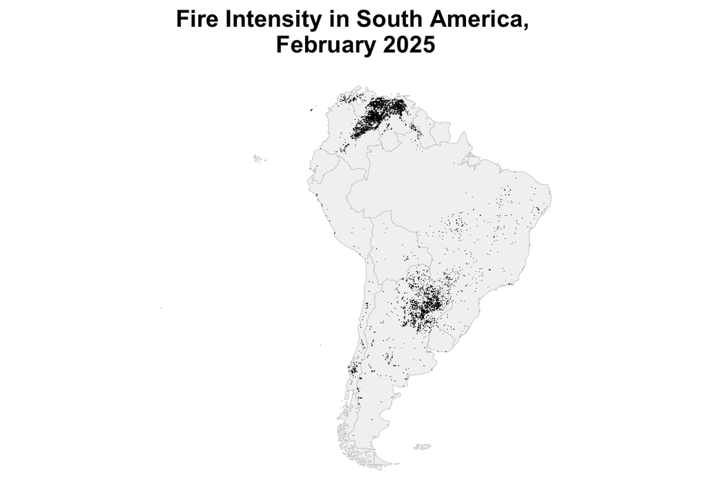

The distribution of wildfire focal points across Latin America in February 2025 reveals distinct regional patterns. The most intense clusters appear in northern South America, particularly Venezuela and Colombia, where fire detections are heavily concentrated. Another notable hotspot is in southern Paraguay and northern Argentina, particularly in the Gran Chaco region, an area that frequently experiences deforestation-related fires.

In Brazil, fire focal points are more dispersed but still present across different ecosystems. While the Amazon Basin shows some activity, it is not as concentrated as in peak fire seasons (July–September).

To show this contrast, here is a visualization of the wild fire focal points from August 2024:

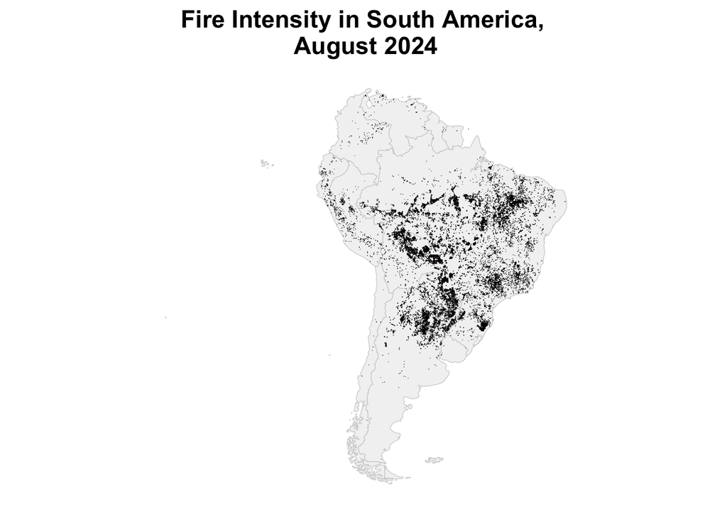

In August 2024, there was a dramatic increase in wildfire focal points across South America, particularly in Brazil. The Amazon, Cerrado, and Pantanal biomes experience a surge in fire activity, with intense burning observed in states such as Amazonas, Mato Grosso, Pará, and Rondônia. This period is known for land-clearing fires associated with deforestation and pasture expansion. Bahia also experiences a notable increase in fire points.